# ESS330 Lab_08

Author

Caleb Cripe

# Data Import/Tidy/Transform

```r
options(repos = c(CRAN = "https://cloud.r-project.org/"))
library(tidyverse)
library(tidymodels)
library(powerjoin)
library(glue)
library(vip)
library(baguette)
library(dplyr)
library(tidyr)
library(skimr)
library(visdat)
library(ggpubr)
library(ggplot2)
library(ggthemes)
library(ranger)
library(dials)
library(patchwork)
```

```r
root  <- 'https://gdex.ucar.edu/dataset/camels/file'

download.file('https://gdex.ucar.edu/dataset/camels/file/camels_attributes_v2.0.pdf',
              'data/camels_attributes_v2.0.pdf')

types <- c("clim", "geol", "soil", "topo", "vege", "hydro")

remote_files  <- glue('{root}/camels_{types}.txt')
local_files   <- glue('data/camels_{types}.txt')

walk2(remote_files, local_files, download.file, quiet = TRUE)

camels <- map(local_files, read_delim, show_col_types = FALSE)

camels <- power_full_join(camels ,by = 'gauge_id')
```

```r
glimpse(camels)
```

```
Rows: 671
Columns: 58
$ gauge_id             <chr> "01013500", "01022500", "01030500", "01031500", "…
$ p_mean               <dbl> 3.126679, 3.608126, 3.274405, 3.522957, 3.323146,…
$ pet_mean             <dbl> 1.971555, 2.119256, 2.043594, 2.071324, 2.090024,…
$ p_seasonality        <dbl> 0.187940259, -0.114529586, 0.047358189, 0.1040905…
$ frac_snow            <dbl> 0.3134404, 0.2452590, 0.2770184, 0.2918365, 0.280…
$ aridity              <dbl> 0.6305587, 0.5873564, 0.6241114, 0.5879503, 0.628…
$ high_prec_freq       <dbl> 12.95, 20.55, 17.15, 18.90, 20.10, 13.50, 17.50, …
$ high_prec_dur        <dbl> 1.348958, 1.205279, 1.207746, 1.148936, 1.165217,…
$ high_prec_timing     <chr> "son", "son", "son", "son", "son", "jja", "son", …
$ low_prec_freq        <dbl> 202.20, 233.65, 215.60, 227.35, 235.90, 193.50, 2…
$ low_prec_dur         <dbl> 3.427119, 3.662226, 3.514262, 3.473644, 3.691706,…
$ low_prec_timing      <chr> "mam", "jja", "djf", "djf", "djf", "mam", "mam", …
$ geol_1st_class       <chr> "Siliciclastic sedimentary rocks", "Acid plutonic…
```

[output cut: 45 more lines]

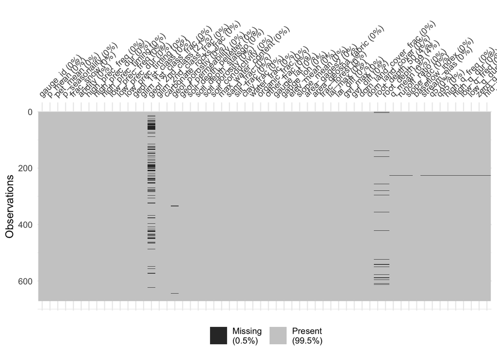

```r
vis_miss(camels)
```

```r
camels_clean <- camels %>%
  distinct() %>%
  drop_na()

skim(camels_clean)
```

Data summary

| Name | camels_clean |
| --- | --- |
| Number of rows | 507 |
| Number of columns | 58 |
| _______________________ |  |
| Column type frequency: |  |
| character | 6 |
| numeric | 52 |
| ________________________ |  |
| Group variables | None |

**Variable type: character**

| skim_variable | n_missing | complete_rate | min | max | empty | n_unique | whitespace |
| --- | --- | --- | --- | --- | --- | --- | --- |
| gauge_id | 0 | 1 | 8 | 8 | 0 | 507 | 0 |
| high_prec_timing | 0 | 1 | 3 | 3 | 0 | 4 | 0 |
| low_prec_timing | 0 | 1 | 3 | 3 | 0 | 4 | 0 |
| geol_1st_class | 0 | 1 | 12 | 31 | 0 | 12 | 0 |
| geol_2nd_class | 0 | 1 | 12 | 31 | 0 | 13 | 0 |
| dom_land_cover | 0 | 1 | 12 | 38 | 0 | 12 | 0 |

**Variable type: numeric**

| skim_variable | n_missing | complete_rate | mean | sd | p0 | p25 | p50 | p75 | p100 | hist |
| --- | --- | --- | --- | --- | --- | --- | --- | --- | --- | --- |
| p_mean | 0 | 1 | 3.15 | 1.49 | 0.64 | 2.20 | 3.05 | 3.70 | 8.94 | ▅▇▂▁▁ |
| pet_mean | 0 | 1 | 2.80 | 0.56 | 1.94 | 2.37 | 2.70 | 3.16 | 4.74 | ▇▇▅▂▁ |
| p_seasonality | 0 | 1 | -0.06 | 0.56 | -1.44 | -0.41 | 0.08 | 0.27 | 0.92 | ▂▃▃▇▃ |
| frac_snow | 0 | 1 | 0.19 | 0.21 | 0.00 | 0.04 | 0.11 | 0.26 | 0.91 | ▇▂▁▁▁ |
| aridity | 0 | 1 | 1.13 | 0.67 | 0.22 | 0.73 | 0.89 | 1.45 | 5.21 | ▇▃▁▁▁ |
| high_prec_freq | 0 | 1 | 21.00 | 4.80 | 7.90 | 18.45 | 22.20 | 24.55 | 32.70 | ▂▃▇▇▁ |
| high_prec_dur | 0 | 1 | 1.37 | 0.19 | 1.10 | 1.22 | 1.32 | 1.47 | 2.07 | ▇▅▂▁▁ |
| low_prec_freq | 0 | 1 | 256.92 | 36.76 | 169.90 | 233.57 | 259.15 | 286.75 | 348.70 | ▂▅▇▆▁ |
| low_prec_dur | 0 | 1 | 6.29 | 3.46 | 2.79 | 4.42 | 5.14 | 7.21 | 36.51 | ▇▁▁▁▁ |
| glim_1st_class_frac | 0 | 1 | 0.73 | 0.19 | 0.30 | 0.58 | 0.76 | 0.90 | 1.00 | ▂▅▅▆▇ |
| glim_2nd_class_frac | 0 | 1 | 0.19 | 0.13 | 0.00 | 0.08 | 0.19 | 0.30 | 0.49 | ▇▆▆▅▂ |
| carbonate_rocks_frac | 0 | 1 | 0.13 | 0.26 | 0.00 | 0.00 | 0.00 | 0.09 | 1.00 | ▇▁▁▁▁ |
| geol_porostiy | 0 | 1 | 0.12 | 0.06 | 0.01 | 0.07 | 0.12 | 0.17 | 0.28 | ▆▆▇▆▁ |
| geol_permeability | 0 | 1 | -13.86 | 1.13 | -16.50 | -14.66 | -13.90 | -13.03 | -10.97 | ▂▃▇▅▁ |
| soil_depth_pelletier | 0 | 1 | 9.45 | 15.25 | 0.27 | 1.00 | 1.20 | 6.99 | 50.00 | ▇▁▁▁▁ |
| soil_depth_statsgo | 0 | 1 | 1.28 | 0.27 | 0.40 | 1.08 | 1.42 | 1.50 | 1.50 | ▁▁▂▂▇ |
| soil_porosity | 0 | 1 | 0.44 | 0.02 | 0.37 | 0.43 | 0.44 | 0.46 | 0.59 | ▁▇▂▁▁ |
| soil_conductivity | 0 | 1 | 1.67 | 1.39 | 0.45 | 0.89 | 1.34 | 1.89 | 10.91 | ▇▁▁▁▁ |
| max_water_content | 0 | 1 | 0.52 | 0.15 | 0.09 | 0.41 | 0.53 | 0.64 | 0.88 | ▁▃▆▇▁ |
| sand_frac | 0 | 1 | 35.69 | 15.47 | 8.18 | 24.62 | 34.60 | 43.77 | 91.16 | ▅▇▅▁▁ |
| silt_frac | 0 | 1 | 33.30 | 12.82 | 4.13 | 23.53 | 33.65 | 42.76 | 67.77 | ▂▇▇▅▁ |
| clay_frac | 0 | 1 | 20.35 | 9.81 | 2.08 | 13.82 | 18.88 | 26.58 | 50.35 | ▃▇▅▂▁ |
| water_frac | 0 | 1 | 0.02 | 0.15 | 0.00 | 0.00 | 0.00 | 0.00 | 1.71 | ▇▁▁▁▁ |
| organic_frac | 0 | 1 | 0.45 | 2.97 | 0.00 | 0.00 | 0.00 | 0.00 | 39.37 | ▇▁▁▁▁ |
| other_frac | 0 | 1 | 10.88 | 16.94 | 0.00 | 0.00 | 2.25 | 15.48 | 89.87 | ▇▂▁▁▁ |
| gauge_lat | 0 | 1 | 39.55 | 5.21 | 27.05 | 36.23 | 39.35 | 43.96 | 48.66 | ▂▃▇▅▆ |
| gauge_lon | 0 | 1 | -98.08 | 16.26 | -124.39 | -112.03 | -97.04 | -83.40 | -67.94 | ▇▆▇▇▅ |
| elev_mean | 0 | 1 | 842.40 | 824.66 | 21.75 | 278.50 | 492.06 | 1055.30 | 3457.46 | ▇▂▁▁▁ |
| slope_mean | 0 | 1 | 50.12 | 48.29 | 0.82 | 7.97 | 36.17 | 77.62 | 255.69 | ▇▃▂▁▁ |
| area_gages2 | 0 | 1 | 854.89 | 1829.26 | 4.03 | 151.12 | 383.82 | 855.14 | 25791.04 | ▇▁▁▁▁ |
| area_geospa_fabric | 0 | 1 | 870.19 | 1837.52 | 4.10 | 164.23 | 397.25 | 861.21 | 25817.78 | ▇▁▁▁▁ |
| frac_forest | 0 | 1 | 0.61 | 0.38 | 0.00 | 0.20 | 0.75 | 0.97 | 1.00 | ▅▁▂▂▇ |
| lai_max | 0 | 1 | 3.00 | 1.52 | 0.37 | 1.63 | 2.75 | 4.60 | 5.58 | ▅▇▃▅▇ |
| lai_diff | 0 | 1 | 2.27 | 1.32 | 0.15 | 1.07 | 2.06 | 3.49 | 4.82 | ▇▇▆▃▆ |
| gvf_max | 0 | 1 | 0.70 | 0.17 | 0.18 | 0.58 | 0.75 | 0.86 | 0.92 | ▁▂▃▃▇ |
| gvf_diff | 0 | 1 | 0.31 | 0.15 | 0.03 | 0.18 | 0.29 | 0.45 | 0.65 | ▅▇▅▇▂ |
| dom_land_cover_frac | 0 | 1 | 0.80 | 0.19 | 0.31 | 0.64 | 0.84 | 0.99 | 1.00 | ▁▂▃▃▇ |
| root_depth_50 | 0 | 1 | 0.18 | 0.03 | 0.12 | 0.16 | 0.18 | 0.19 | 0.25 | ▃▅▇▂▂ |
| root_depth_99 | 0 | 1 | 1.81 | 0.30 | 1.50 | 1.51 | 1.79 | 2.00 | 3.10 | ▇▃▂▁▁ |
| q_mean | 0 | 1 | 1.46 | 1.61 | 0.00 | 0.49 | 1.00 | 1.72 | 9.50 | ▇▁▁▁▁ |
| runoff_ratio | 0 | 1 | 0.38 | 0.24 | 0.00 | 0.22 | 0.34 | 0.51 | 1.36 | ▇▇▃▁▁ |
| slope_fdc | 0 | 1 | 1.19 | 0.53 | 0.00 | 0.81 | 1.24 | 1.56 | 2.50 | ▃▆▇▆▁ |
| baseflow_index | 0 | 1 | 0.49 | 0.17 | 0.01 | 0.39 | 0.51 | 0.60 | 0.98 | ▁▃▇▅▁ |
| stream_elas | 0 | 1 | 1.86 | 0.80 | -0.64 | 1.33 | 1.69 | 2.25 | 6.24 | ▁▇▃▁▁ |
| q5 | 0 | 1 | 0.17 | 0.25 | 0.00 | 0.01 | 0.08 | 0.22 | 1.77 | ▇▁▁▁▁ |
| q95 | 0 | 1 | 4.98 | 5.23 | 0.00 | 1.67 | 3.46 | 6.29 | 31.23 | ▇▂▁▁▁ |
| high_q_freq | 0 | 1 | 27.15 | 30.51 | 0.00 | 6.92 | 16.15 | 38.60 | 172.80 | ▇▂▁▁▁ |
| high_q_dur | 0 | 1 | 7.62 | 10.98 | 0.00 | 1.87 | 3.24 | 8.82 | 92.56 | ▇▁▁▁▁ |
| low_q_freq | 0 | 1 | 111.13 | 86.38 | 0.00 | 35.35 | 101.35 | 173.10 | 356.80 | ▇▆▅▂▁ |
| low_q_dur | 0 | 1 | 23.38 | 23.12 | 0.00 | 10.31 | 16.92 | 28.20 | 209.88 | ▇▁▁▁▁ |
| zero_q_freq | 0 | 1 | 0.04 | 0.13 | 0.00 | 0.00 | 0.00 | 0.00 | 0.97 | ▇▁▁▁▁ |
| hfd_mean | 0 | 1 | 185.49 | 34.66 | 112.25 | 162.07 | 177.80 | 212.10 | 287.75 | ▂▇▅▃▁ |

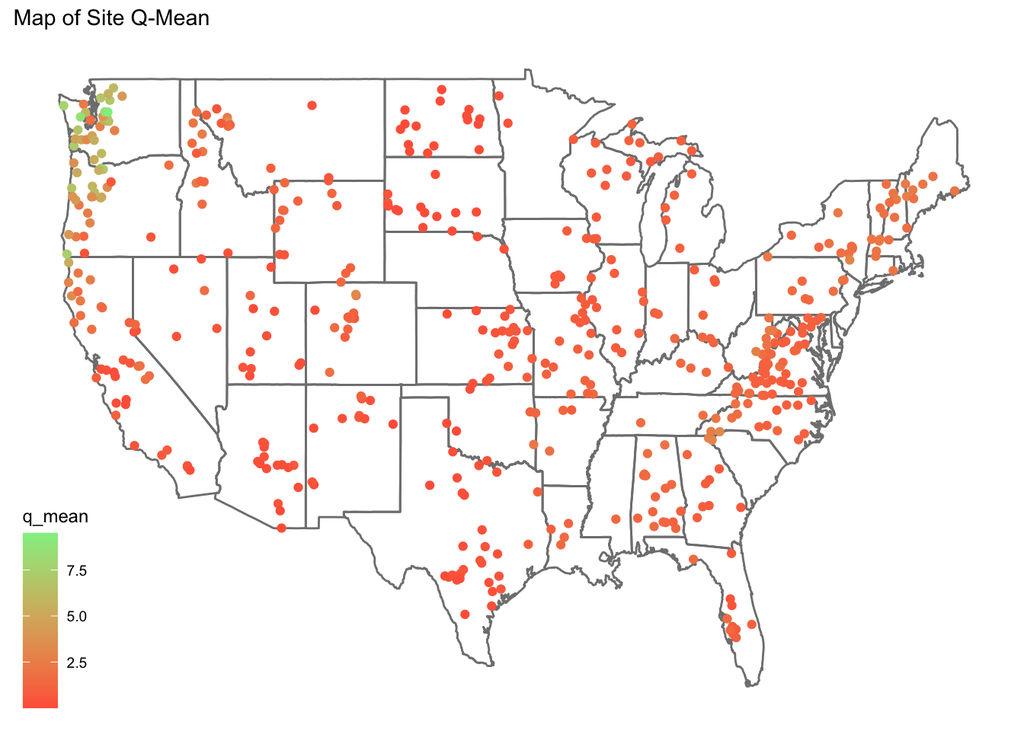

```r
map_qmean <- ggplot(data = camels_clean, aes(x = gauge_lon, y = gauge_lat)) +
  borders("state", colour = "gray50") +
  geom_point(aes(color = q_mean)) +
  scale_color_gradient(low = "tomato", high = "lightgreen") +
  ggthemes::theme_map() +
  ggtitle("Map of Site Q-Mean") +
  labs(color = "q_mean")

print(map_qmean)
```

# Data Splitting

```r
set.seed(64)

camels_clean <- camels_clean |>
  mutate(logQmean = log(q_mean))

cc_split <- initial_split(camels_clean, prop = 0.8)
cc_train <- training(cc_split)
cc_test  <- testing(cc_split)
```

# Feature Engineering

```r
recipe_cc <-  recipe(logQmean ~ aridity + p_mean, data = cc_train) %>%
  step_log(all_predictors()) %>%
  step_interact(terms = ~ aridity:p_mean) |>
  step_naomit(all_predictors(), all_outcomes())

cc_baked_data <- prep(recipe_cc, cc_train) |>
  bake(new_data = NULL)
```

# Resampling and Model Testing

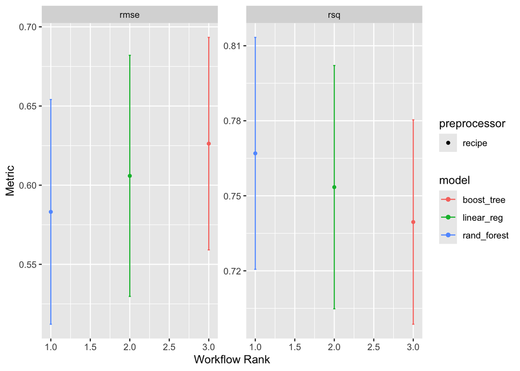

```r
camels_cc_cv <- vfold_cv(cc_train, v = 10)

lm_model_cc <- linear_reg() %>%
  set_engine("lm") %>%
  set_mode("regression")

lm_wf_cc <- workflow() %>%
  add_recipe(recipe_cc) %>%
  add_model(lm_model_cc) %>%
  fit(data = cc_train)

rf_model_cc <- rand_forest() %>%
  set_engine("ranger", importance = "impurity") %>%
  set_mode("regression")

rf_wf_cc <- workflow() %>%
  add_recipe(recipe_cc) %>%
  add_model(rf_model_cc) %>%
  fit(data = cc_train)

xg_model_cc <- boost_tree() %>%
  set_engine("xgboost") %>%
  set_mode("regression")

xg_wf_cc <- workflow() %>%
  add_recipe(recipe_cc) %>%
  add_model(xg_model_cc) %>%
  fit(data = cc_train)

wf_cc <- workflow_set(list(recipe_cc), list(lm_model_cc, rf_model_cc, xg_model_cc)) %>%
  workflow_map('fit_resamples', resamples = camels_cc_cv)

autoplot(wf_cc)
```

After visualizing the model metrics, I selected the random forest model for my model tuning. The random forest model has the highest rsq value out of the three models, as well as having the lowest mean standard error. Random forest is a regression model, which I have chosen to run with the “ranger” engine. I think it will work well for this problems because it handles nonlinear relationships efficiently and reduces overfitting.

# Model Tuning

```r
rf_tuned_cc <- rand_forest(
  mtry = tune(),
  trees = tune()
) %>%
  set_engine("ranger", importance = "impurity") %>%
  set_mode("regression")

rf_wf_cc <- workflow() %>%
  add_recipe(recipe_cc) %>%
  add_model(rf_tuned_cc)

dials <- extract_parameter_set_dials(rf_tuned_cc) %>%
  finalize(cc_train)

dials$object
```

```
[[1]]
# Randomly Selected Predictors (quantitative)
Range: [1, 59]

[[2]]
# Trees (quantitative)
Range: [1, 2000]
```

```r
set.seed(64)
my.grid <- grid_space_filling(dials, size = 25)
```

```r
model_params <-  tune_grid(
    rf_wf_cc,
    resamples = camels_cc_cv,
    grid = my.grid,
    metrics = metric_set(rmse, rsq, mae),
    control = control_grid(save_pred = TRUE)
  )
```

[output not shown]

```
There were issues with some computations   A: x1
```

[output not shown]

[output not shown]

[output cut: 46 more lines]

[output not shown]

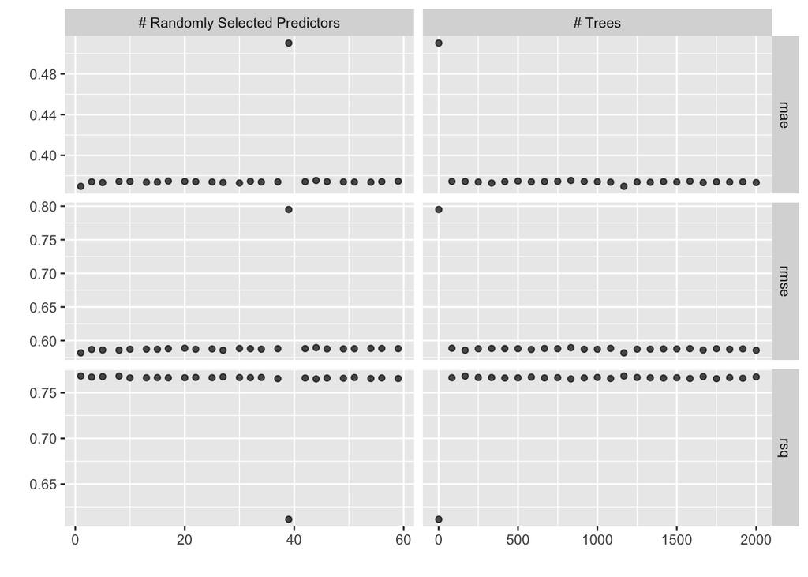

```r
autoplot(model_params)
```

After visualizing the results of the tuning process, I found that the mae, rmse, and rsq were pretty consistent for both the randomly selected predictor and the # of trees. This indicates that I can select a lower trees value and still get the same results as a higher value.

```r
collect_metrics(model_params)
```

```
# A tibble: 75 × 8
    mtry trees .metric .estimator  mean     n std_err .config
   <int> <int> <chr>   <chr>      <dbl> <int>   <dbl> <chr>
 1     1  1167 mae     standard   0.370    10  0.0225 Preprocessor1_Model01
 2     1  1167 rmse    standard   0.582    10  0.0430 Preprocessor1_Model01
 3     1  1167 rsq     standard   0.768    10  0.0283 Preprocessor1_Model01
 4     3   584 mae     standard   0.374    10  0.0235 Preprocessor1_Model02
 5     3   584 rmse    standard   0.587    10  0.0442 Preprocessor1_Model02
 6     3   584 rsq     standard   0.767    10  0.0287 Preprocessor1_Model02
 7     5  1666 mae     standard   0.373    10  0.0238 Preprocessor1_Model03
 8     5  1666 rmse    standard   0.586    10  0.0446 Preprocessor1_Model03
 9     5  1666 rsq     standard   0.768    10  0.0289 Preprocessor1_Model03
10     8   167 mae     standard   0.374    10  0.0228 Preprocessor1_Model04
# ℹ 65 more rows
```

```r
show_best(model_params, metric = "mae")
```

```
# A tibble: 5 × 8
   mtry trees .metric .estimator  mean     n std_err .config
  <int> <int> <chr>   <chr>      <dbl> <int>   <dbl> <chr>
1     1  1167 mae     standard   0.370    10  0.0225 Preprocessor1_Model01
2    30   334 mae     standard   0.373    10  0.0232 Preprocessor1_Model13
3     5  1666 mae     standard   0.373    10  0.0238 Preprocessor1_Model03
4    27  2000 mae     standard   0.373    10  0.0234 Preprocessor1_Model12
5    13  1333 mae     standard   0.374    10  0.0235 Preprocessor1_Model06
```

```r
hp_best <- select_best(model_params, metric = "mae")
```

```r
rf_final_wf <- finalize_workflow(
  rf_wf_cc,
  hp_best
)
```

# Final Model Verification

```r
rf_final_fit <- last_fit(
  rf_final_wf,
  split = cc_split
)

collect_metrics(rf_final_fit)
```

```
# A tibble: 2 × 4
  .metric .estimator .estimate .config
  <chr>   <chr>          <dbl> <chr>
1 rmse    standard       0.603 Preprocessor1_Model1
2 rsq     standard       0.799 Preprocessor1_Model1
```

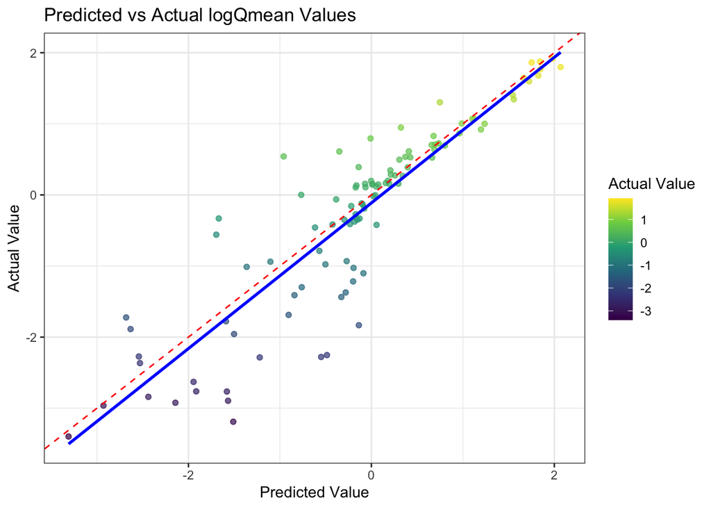

```r
predictions <- collect_predictions(rf_final_fit)

ggplot(predictions, aes(x = .pred, y = logQmean)) +
  geom_point(aes(color = logQmean), alpha = 0.7) +
  geom_smooth(method = "lm", se = FALSE, color = "blue") +
  geom_abline(linetype = "dashed", color = "red") +
  scale_color_viridis_c() +
  labs(
    title = "Predicted vs Actual logQmean Values",
    x = "Predicted Value",
    y = "Actual Value",
    color = "Actual Value"
  ) +
  theme_bw()
```

Against the test data, there is a strong correlation between the models predicted data and the actual data. Most of the plots on the graph align with the line, indicating that while there is some prediction error at extreme case points, majority of the predicted data was accurate.

# Building a Map

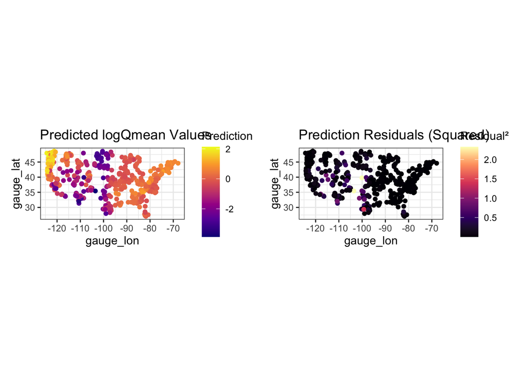

```r
final_rf_fit <- fit(rf_final_wf, data = camels_clean)

rf_predictions <- augment(final_rf_fit, new_data = camels_clean) %>%
  mutate(residual = (.pred - logQmean)^2)

prediction_map <- ggplot(rf_predictions, aes(x = gauge_lon, y = gauge_lat, color = .pred)) +
  geom_point(size = 1.5) +
  scale_color_viridis_c(option = "plasma") +
  coord_fixed(1.3) +
  labs(title = "Predicted logQmean Values", color = "Prediction") +
  theme_bw()

resid_map <- ggplot(rf_predictions, aes(x = gauge_lon, y = gauge_lat, color = residual)) +
  geom_point(size = 1.5) +
  scale_color_viridis_c(option = "magma") +
  coord_fixed(1.3) +
  labs(title = "Prediction Residuals (Squared)", color = "Residual²") +
  theme_bw()

prediction_map + resid_map
```